# PSV Analysis

## 1.4 Vehicle - Overall

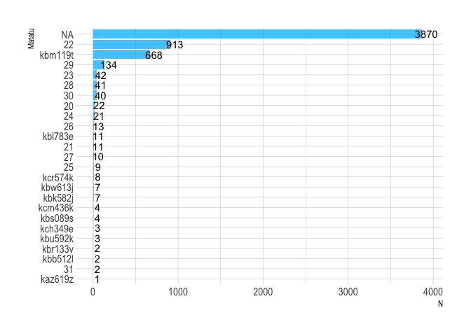

```r
data %>%
  filter(!is.na(complete_date)) %>%
  filter(!is.na(matatu_no)) %>%
  group_by(matatu_no_clean) %>%
  dplyr::summarise(N = n()) %>%
  ggplot(aes(x = reorder(matatu_no_clean, N), y = N)) +
  geom_col(fill = "deepskyblue", alpha=0.8) +
  geom_text(aes(label = N), nudge_y = 50) +
  labs(x = "Matatu", y = "N") +
  coord_flip() +
  theme_ipsum()
```

## 1.5 Hourly - By Vehicle

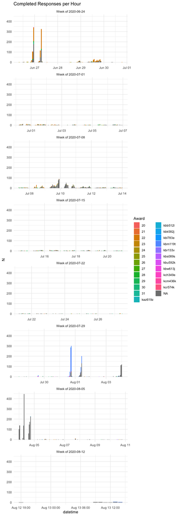

```r
data %>%
    filter(!is.na(complete_date)) %>%
  mutate(datetime = complete_date %>% round_date(unit = "hour")) %>%
  filter(!is.na(datetime)) %>%
  group_by(datetime, week_date, matatu_no_clean) %>%
  dplyr::summarise(N = n()) %>%
  ungroup() %>%
  mutate(week_date = paste("Week of", week_date)) %>%
  ggplot() +
  geom_col(aes(x = datetime, y = N,
               group = matatu_no_clean,
               fill = matatu_no_clean)) +
  labs(title = "Completed Responses per Hour",
       fill = "Award") +
  facet_wrap(~week_date, ncol = 1, scale = "free_x") +
  theme_minimal()
```

## 1.6 Response by Hour Histogram

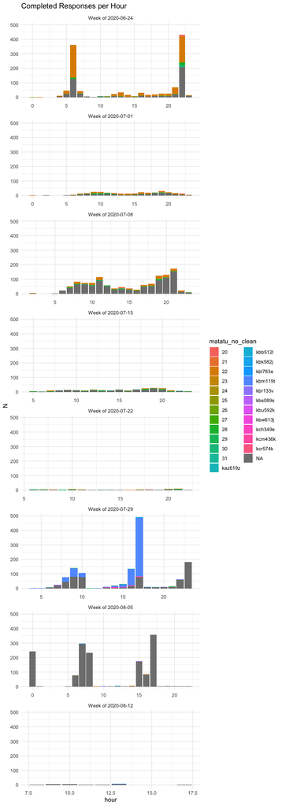

```r
data %>%
    filter(!is.na(complete_date)) %>%
  group_by(hour, week_date, matatu_no_clean) %>%
  dplyr::summarise(N = n()) %>%
  ungroup() %>%
  mutate(week_date = paste("Week of", week_date)) %>%
  ggplot() +
  geom_col(aes(x = hour, y = N,
               fill = matatu_no_clean,
               group = matatu_no_clean)) +
  labs(title = "Completed Responses per Hour") +
  facet_wrap(~week_date, ncol = 1, scale = "free_x") +
  theme_minimal()
```

## 1.7 When enter reg no, how incorrect?

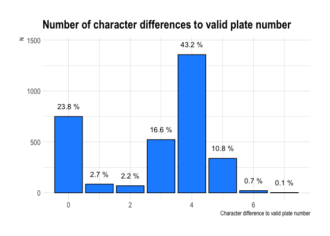

```r
data %>%
  filter(how_identif %in% "reg no",
         !is.na(reg_no_raw)) %>%
  group_by(reg_no_closest_dist) %>%
  dplyr::summarise(N = n()) %>%
  mutate(percent = (N/sum(N)*100) %>% round(1) %>% paste("%")) %>%
  ggplot(aes(x = reg_no_closest_dist, y = N)) +
  geom_col(fill = "dodgerblue", color = "black") +
  geom_text(aes(label = percent), nudge_y = 100) +
  labs(x = "Character difference to valid plate number",
       title = "Number of character differences to valid plate number") +
  theme_ipsum()
```

# 2 Questions by Vehicle

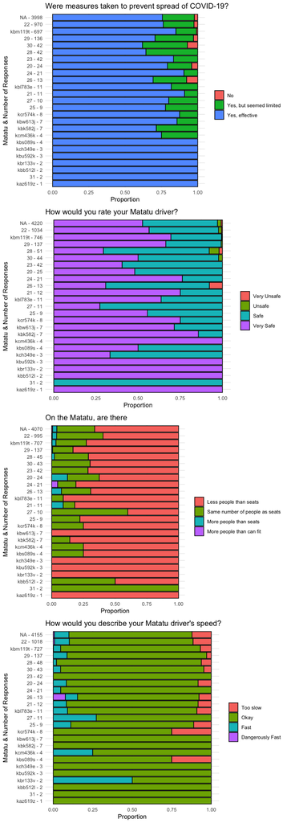

```r
data_long <- data %>%
  dplyr::select(matatu_no_clean,
                driver_rating, speed_rating, occupancy, covid_measures) %>%
  pivot_longer(-matatu_no_clean) %>%

  filter(value != "") %>%

  # Number of responses per question, per vehicle
  group_by(matatu_no_clean, name) %>%
  mutate(N_veh = n()) %>%
  ungroup() %>%

  # Aggregate
  group_by(name, value, matatu_no_clean, N_veh) %>%
  summarise(N = n()) %>%
  ungroup()  %>%

  # Clean variables
  mutate(matatu_no_clean = paste0(matatu_no_clean, " - ", N_veh)) %>%
  mutate(N = N/N_veh)

data_long$name[data_long$name %in% "driver_rating"] <- "How would you rate your Matatu driver?"
data_long$name[data_long$name %in% "covid_measures"] <- "Were measures taken to prevent spread of COVID-19?"
data_long$name[data_long$name %in% "occupancy"] <- "On the Matatu, are there"
data_long$name[data_long$name %in% "speed_rating"] <- "How would you describe your Matatu driver's speed?"

data_long$value <- data_long$value %>% str_squish()

data_long$value <- factor(data_long$value, levels = c("No",
                                                      "Yes, but seemed limited",
                                                      "Yes, effective",

                                                      "Very Unsafe",
                                                      "Unsafe",
                                                      "Safe",
                                                      "Very Safe",

                                                      "Less people than seats",
                                                      "Same number of people as seats",
                                                      "More people than seats",
                                                      "More people than can fit",

                                                      "Too slow",
                                                      "Okay",
                                                      "Fast",
                                                      "Dangerously Fast"))

out_plot <- lapply(data_long$name %>% unique, function(i){

  data_long %>%
    filter(name %in% i) %>%
    ggplot(aes(x = reorder(matatu_no_clean, N_veh), #
               y = N, group=value, fill=value)) +
    geom_col(color="black") +
    labs(x="", y="",
         title = i) +
    theme_minimal() +
    coord_flip() +
    labs(x = "Matatu & Number of Responses", y = "Proportion", fill = "")

})

do.call(grid.arrange, c(out_plot, ncol=1))
```

# 3 Feedback

## 3.1 Number of Words - Histogram

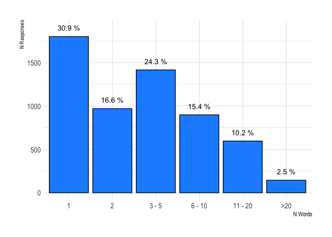

```r
# TO DO: Put into buckets and show % -- use geom_col

data$feedback_nwords_bin <- NA
data$feedback_nwords_bin[data$feedback_nwords %in% 1] <- "1"
data$feedback_nwords_bin[data$feedback_nwords %in% 2] <- "2"
data$feedback_nwords_bin[data$feedback_nwords %in% 3:5] <- "3 - 5"
data$feedback_nwords_bin[data$feedback_nwords %in% 6:10] <- "6 - 10"
data$feedback_nwords_bin[data$feedback_nwords %in% 11:20] <- "11 - 20"
data$feedback_nwords_bin[data$feedback_nwords %in% 21:9999] <- ">20"

data$feedback_nwords_bin <- data$feedback_nwords_bin %>%
  factor(levels = c("1", "2", "3 - 5",
                    "6 - 10", "11 - 20", ">20"))

data %>%
  filter(feedback_nwords > 0) %>%
  group_by(feedback_nwords_bin) %>%
  dplyr::summarise(N = n()) %>%
  ungroup() %>%
  mutate(percent = (N/sum(N)*100) %>% round(1) %>% paste("%")) %>%
  ggplot(aes(x = feedback_nwords_bin,
             y = N)) +
  geom_col(fill = "dodgerblue", color = "black") +
  geom_text(aes(label = percent), nudge_y = 100) +
  labs(x = "N Words",
       y = "N Responses") +
  theme_ipsum()
```

## 3.2 Responses - All

```r
data %>%
  filter(feedback_nwords > 0) %>%
  arrange(desc(feedback_nwords)) %>%
  dplyr::select(feedback, matatu_no_clean) %>%
  dplyr::rename("Matatu" = matatu_no_clean,
                Feedback = feedback) %>%
  paged_table()
```

| Feedback | Matatu |
| --- | --- |
| Our Matatu System Has Really Evolved Over The Years And We Have Experienced Much Since The Commencement...I Believe With The Rapid Changes We Can Improve Even More...Many Policies Put In Place Should … | NA |
| Yeah sure,all i wold recomend is the traffic police to b more keen on this route as there are no any health measures being taken....passangers are being mistreated .i suppose that the government b mor… | NA |
| 1. Due to the COVID- 19 pandemic the matatu drivers shouldn't give up in providing the hand sanitizers to passengers so as to flatten the curve of this virus.2. Matatu drivers are just okay, that's a … | NA |
| Maybe to the said about drivers who are corrupt giving bribes and using other routes,, to take caution and let them know they will suffer alot as the disease is spreading faster due to their ignorance… | 22 |
| I like my driver and the conductor for being on the first line in the fight against Covid 19 by adhering to the MOH directives, they do not exceed the 8 passengers in the 14 seater matatu and they don… | NA |
| compliment my driver for taking the best measures that have been directed by NTSA & the ministry of health. 1. No excess passangers. 2. No overspeeding and reckless driving3. Recomends all passangers … | NA |
| To the driver it's quite a trial with your team on measures you're supposed to take to control this Corona pandemic. You ought to do more and be more strict on this . Otherwise I enjoyed the drive...i… | NA |
| Well on my part I can say that the operators of the matatu took all the necessary measures to try and mitigate the spread of Covid 19 as well as following the rules and regulations that guide road use… | 22 |
| This driver drives okay,not fast but not too slow,,,passengers are seated as required by the social distance guide,as directed by govt but measures on sanitizing the passengers should be more enhanced… | 22 |
| I appreciate the driver for making sure that all passengers are safe,partaining the current pandemic of covid_19 we are facing,for installing the preventive measures equipments in the matatu like sani… | 22 |

[output cut: 5819 more lines]

## 3.3 Responses - Driver Unsafe or Very Unsafe

```r
data %>%
  filter(feedback_nwords > 0,
         driver_rating %in% c("Unsafe", "Very Unsafe")) %>%
  arrange(desc(feedback_nwords)) %>%
  dplyr::select(feedback, matatu_no_clean) %>%
  dplyr::rename("Matatu" = matatu_no_clean,
                Feedback = feedback) %>%
  paged_table()
```

| Feedback | Matatu |
| --- | --- |
| Yeah sure,all i wold recomend is the traffic police to b more keen on this route as there are no any health measures being taken....passangers are being mistreated .i suppose that the government b mor… | NA |
| Drivers should learn how to obey traffic laws and driver carefully keeping in mind that they are entrusted with the life of their passengers. Thank you. | NA |
| Our police personnel are not taking good look on the reckless drivers and our drivers should also be given advice on the importance of good driving. | NA |
| The driver was very fast because mostly they wanted to reach their destination putting passengers lives in danger mostly matatus from town to umoja | 22 |
| Some drivers are careful but other seem not to care at all, let all drivers always protect the life entrusted to them by passengers | 22 |
| Matatus should be kept in good condition , measures against covid 19 should be enforced, n road safety rules should be adhered to strictly | NA |
| Matatu driver to follow guidelines given by ministry of health to stop spread Corona virus and to keep their passengers safe | NA |
| The matatu should be well equiped to avoid spread of covid 19 and ensure every passenger wears a mask correctly | 22 |
| Advise to be given to the matatu sector on healthy ways towards prevention of spread of the Covid-19 | NA |
| Compilment the driver because he seems to be driving fast to reach the destination before the curfew | NA |

[output cut: 134 more lines]

# 4 Number of Questions Answered

## 4.1 Overall - 6 Qs Survey

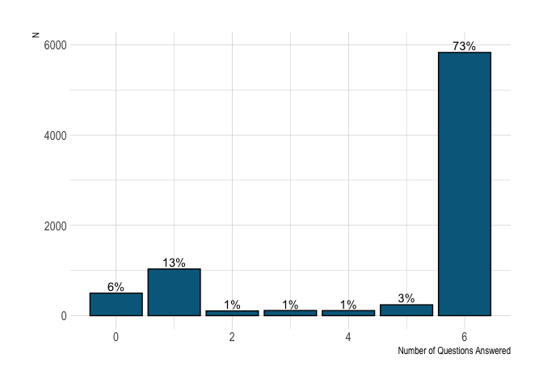

```r
data %>%
  filter(N_questions %in% 6) %>%
  group_by(N_qs_answered) %>%
  dplyr::summarise(N = n()) %>%
  ungroup() %>%
  dplyr::mutate(prop = (round(N / sum(N),2)*100) %>% paste0("%")) %>%
  ggplot(aes(x = N_qs_answered, y = N)) +
  geom_col(fill = "deepskyblue4", color = "black") +
  geom_text(aes(label = prop), nudge_y = 150) +
  labs(x = "Number of Questions Answered") +
  theme_ipsum()
```

## 4.2 By Vehicle - 6 Qs Survey

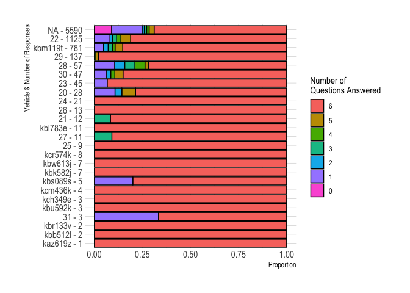

```r
data %>%

  filter(N_questions %in% 6) %>%

  mutate(N_qs_answered = N_qs_answered %>% as.factor() %>% fct_rev) %>%

  # Number of responses per question, per vehicle
  group_by(matatu_no_clean) %>%
  mutate(N_veh = n()) %>%
  ungroup() %>%

  group_by(N_qs_answered, matatu_no_clean, N_veh) %>%
  dplyr::summarise(N = n()) %>%
  ungroup() %>%

  mutate(prop = N / N_veh) %>%

  mutate(matatu_no_clean = paste0(matatu_no_clean, " - ", N_veh)) %>%

  ggplot(aes(x = reorder(matatu_no_clean, N_veh), y = prop,
             group = N_qs_answered,
             fill = N_qs_answered)) +
  geom_col(color = "black") +
  labs(x = "Vehicle & Number of Responses", y = "Proportion",
       fill = "Number of\nQuestions Answered") +
  coord_flip() +
  theme_ipsum()
```

## 4.3 Overall - 3 Qs Survey

After realizing we are low on funds after the 50 KES, we lowered the award to 10 KES and the number of questions to 3. This is clearly indicated at the start of the survey. The first message received in the shortcode is:

*"Welcome to this 3 question survey. **We’ve lowered the award to 10 KES***

*What is the matatu reg. number? (Written on sticker)."*

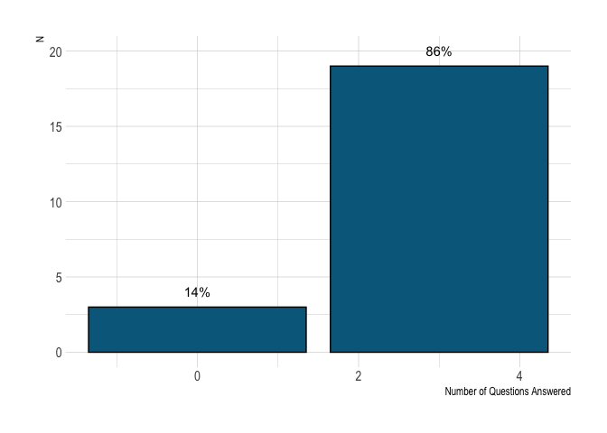

```r
data %>%
  filter(N_questions %in% 3) %>%
  group_by(N_qs_answered) %>%
  dplyr::summarise(N = n()) %>%
  ungroup() %>%
  dplyr::mutate(prop = (round(N / sum(N),2)*100) %>% paste0("%")) %>%
  ggplot(aes(x = N_qs_answered, y = N)) +
  geom_col(fill = "deepskyblue4", color = "black") +
  geom_text(aes(label = prop), nudge_y = 1) +
  labs(x = "Number of Questions Answered") +
  theme_ipsum()
```